# Quiz 2 - Solutions

Maria Cuellar

2026-10-08

# Question 1 (5 points)

Load the dat.nsduh.small.csv dataset.

```r
library(tidyverse)
dat_nsduh <- read_csv("/Users/mariacuellar/Github/crim_data_analysis/data/dat.nsduh.small.csv")
```

# Question 2 (5 points)

Perform visual EDA for x=mjage and y=cigage. Describe your plot. (Note: you can include a line of best fit, but it is not necessary at this point.)

Answer:

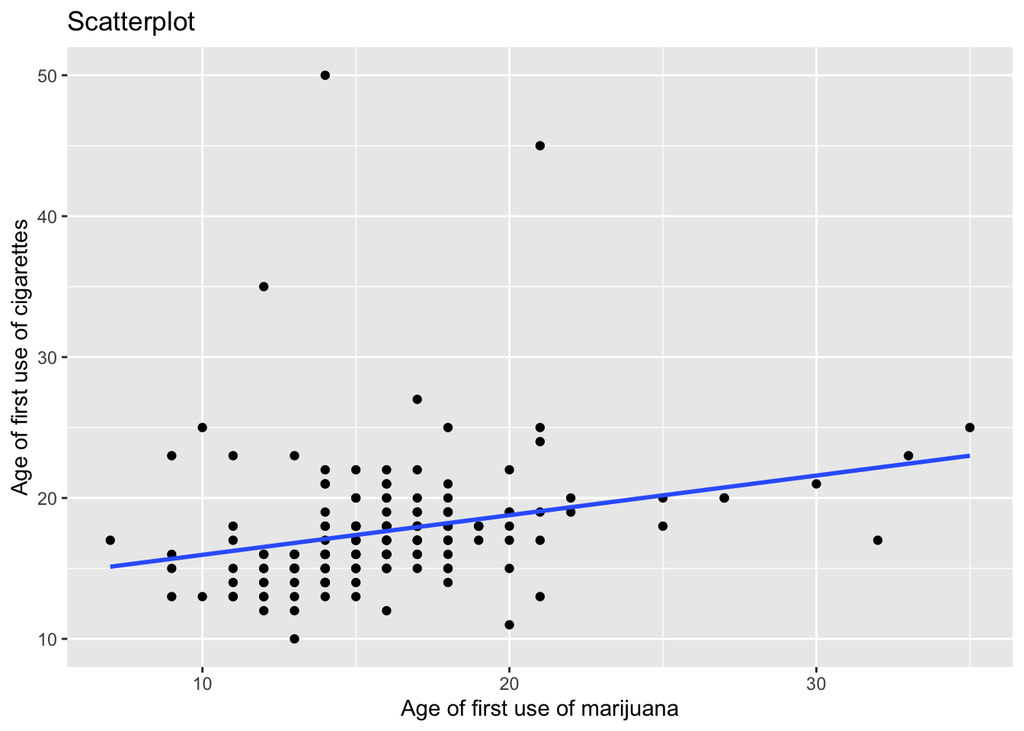

```r
dat_nsduh %>% ggplot(aes(x=mjage, y=cigage)) +
  geom_point() +
  geom_smooth(method="lm", se=FALSE) +
  labs(title="Scatterplot", x="Age of first use of marijuana", y="Age of first use of cigarettes")
```

I drew a scatterplot. There is a positive association that is weak, the relationship seems linear, but there are some outliers.

# Question 3 (5 points)

Fit a linear regression model with cigage as the response and mjage as the explanatory variable. Create a second dataset excluding outliers using this code: dat_nsduh_nooutliers <- dat_nsduh %>% filter(cooks.distance(model) <= 0.05) . Calculate the correlation between the two variables both with and without influential observations. Interpret your results.

```r
dat_nsduh %>% summarize(cor=cor(mjage, cigage))
```

```
## # A tibble: 1 × 1
##     cor
##   <dbl>
## 1 0.252
```

```r
model <- lm(cigage~mjage, dat=dat_nsduh)

dat_nsduh_nooutliers <- dat_nsduh %>% filter(cooks.distance(model) <= 0.05)

dat_nsduh_nooutliers %>% summarize(cor=cor(mjage, cigage))
```

```
## # A tibble: 1 × 1
##     cor
##   <dbl>
## 1 0.418
```

I check the conditions for correlation: yes, the variables are quantitative, the relationship is linear, but there are some outliers. Therefore, I calculate the correlation with (.25) and without (.42) the outliers.

# Question 4 (10 points)

Fit a linear regression model using the dataset without influential observations. Generate the four standard diagnostic plots in R. Evaluate whether the following assumptions are reasonably satisfied: homoscedasticity, independence of errors, linearity, and normality of errors. Explain your reasoning.

Hint: This is real-world data, not simulated. So, try to be super lenient when testing assumptions. If it looks ok for most of the data, then you can say it’s satisfied.

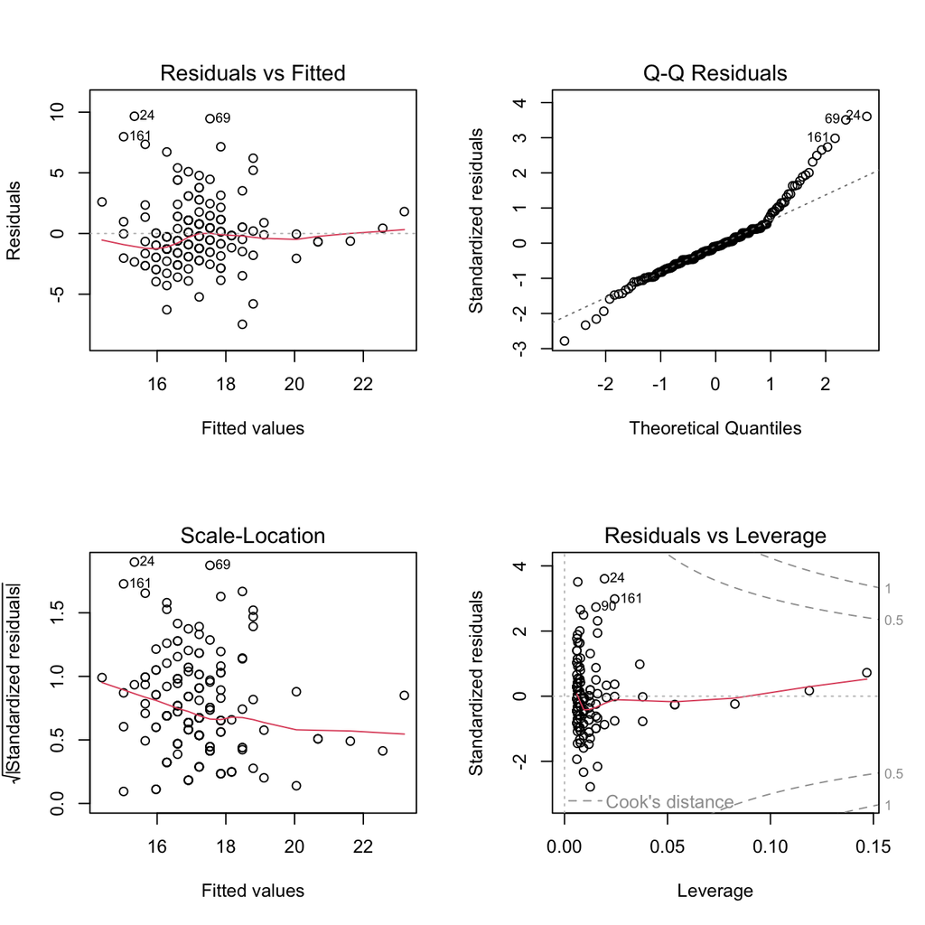

```r
model_nooutliers <- lm(cigage~mjage, dat=dat_nsduh_nooutliers)

par(mfrow = c(2, 2))
plot(model_nooutliers)
```

```r
par(mfrow = c(1, 1))

summary(model_nooutliers)
```

```
##
## Call:
## lm(formula = cigage ~ mjage, data = dat_nsduh_nooutliers)
##
## Residuals:
##     Min      1Q  Median      3Q     Max
## -7.4805 -1.5665 -0.2809  1.0906  9.6618
##
## Coefficients:
##             Estimate Std. Error t value Pr(>|t|)
## (Intercept) 12.19591    0.87061  14.009  < 2e-16 ***
## mjage        0.31423    0.05315   5.912 1.89e-08 ***
## ---
## Signif. codes:  0 '***' 0.001 '**' 0.01 '*' 0.05 '.' 0.1 ' ' 1
##
## Residual standard error: 2.706 on 165 degrees of freedom
## Multiple R-squared:  0.1748, Adjusted R-squared:  0.1698
## F-statistic: 34.95 on 1 and 165 DF,  p-value: 1.89e-08
```

# Question 5 (5 points)

Interpret the slope coefficient and do inference.

Is the association statistically significant at the 0.05 level? Report the p-value.

Answer:

Each additional year of age of first use of marijuana is associated with an additional 0.31 years of age of first use of cigarettes, and this is statistically significant at the 0.05 level, with p<0.001.